# Risk Factor Analysis

## Outcome Variable

**Outcome Variable:** sstunted

## Predictor Variables

**Intervention Variable:** fhtcm

**Adjustment Set:**

- arm
- W_mage
- W_fage
- meducyrs
- feducyrs
- W_mhtcm
- W_mwtkg
- W_mbmi
- single
- delta_W_mage
- delta_W_fage
- delta_meducyrs
- delta_feducyrs
- delta_W_mhtcm
- delta_W_mwtkg
- delta_W_mbmi
- delta_single

## Stratifying Variables

The analysis was stratified on these variable(s):

- agecat
- studyid
- country

## Data Summary

| agecat | studyid | country | fhtcm | sstunted | n_cell | n |
| --- | --- | --- | --- | --- | --- | --- |
| Birth | COHORTS | GUATEMALA | >=167 cm | 0 | 27 | 206 |
| Birth | COHORTS | GUATEMALA | >=167 cm | 1 | 2 | 206 |
| Birth | COHORTS | GUATEMALA | <162 cm | 0 | 119 | 206 |
| Birth | COHORTS | GUATEMALA | <162 cm | 1 | 2 | 206 |
| Birth | COHORTS | GUATEMALA | [162-167) cm | 0 | 56 | 206 |
| Birth | COHORTS | GUATEMALA | [162-167) cm | 1 | 0 | 206 |
| Birth | Keneba | GAMBIA | >=167 cm | 0 | 755 | 1167 |
| Birth | Keneba | GAMBIA | >=167 cm | 1 | 17 | 1167 |
| Birth | Keneba | GAMBIA | <162 cm | 0 | 87 | 1167 |
| Birth | Keneba | GAMBIA | <162 cm | 1 | 0 | 1167 |
| Birth | Keneba | GAMBIA | [162-167) cm | 0 | 304 | 1167 |
| Birth | Keneba | GAMBIA | [162-167) cm | 1 | 4 | 1167 |
| Birth | PROBIT | BELARUS | >=167 cm | 0 | 11737 | 12535 |
| Birth | PROBIT | BELARUS | >=167 cm | 1 | 5 | 12535 |
| Birth | PROBIT | BELARUS | <162 cm | 0 | 168 | 12535 |
| Birth | PROBIT | BELARUS | <162 cm | 1 | 0 | 12535 |
| Birth | PROBIT | BELARUS | [162-167) cm | 0 | 625 | 12535 |
| Birth | PROBIT | BELARUS | [162-167) cm | 1 | 0 | 12535 |
| Birth | SAS-CompFeed | INDIA | >=167 cm | 0 | 329 | 746 |
| Birth | SAS-CompFeed | INDIA | >=167 cm | 1 | 14 | 746 |
| Birth | SAS-CompFeed | INDIA | <162 cm | 0 | 166 | 746 |
| Birth | SAS-CompFeed | INDIA | <162 cm | 1 | 24 | 746 |
| Birth | SAS-CompFeed | INDIA | [162-167) cm | 0 | 197 | 746 |
| Birth | SAS-CompFeed | INDIA | [162-167) cm | 1 | 16 | 746 |
| 6 months | COHORTS | GUATEMALA | >=167 cm | 0 | 42 | 336 |
| 6 months | COHORTS | GUATEMALA | >=167 cm | 1 | 3 | 336 |
| 6 months | COHORTS | GUATEMALA | <162 cm | 0 | 157 | 336 |
| 6 months | COHORTS | GUATEMALA | <162 cm | 1 | 40 | 336 |
| 6 months | COHORTS | GUATEMALA | [162-167) cm | 0 | 85 | 336 |
| 6 months | COHORTS | GUATEMALA | [162-167) cm | 1 | 9 | 336 |
| 6 months | Keneba | GAMBIA | >=167 cm | 0 | 948 | 1511 |
| 6 months | Keneba | GAMBIA | >=167 cm | 1 | 31 | 1511 |
| 6 months | Keneba | GAMBIA | <162 cm | 0 | 111 | 1511 |
| 6 months | Keneba | GAMBIA | <162 cm | 1 | 2 | 1511 |
| 6 months | Keneba | GAMBIA | [162-167) cm | 0 | 403 | 1511 |
| 6 months | Keneba | GAMBIA | [162-167) cm | 1 | 16 | 1511 |
| 6 months | PROBIT | BELARUS | >=167 cm | 0 | 11044 | 11894 |
| 6 months | PROBIT | BELARUS | >=167 cm | 1 | 102 | 11894 |
| 6 months | PROBIT | BELARUS | <162 cm | 0 | 149 | 11894 |
| 6 months | PROBIT | BELARUS | <162 cm | 1 | 7 | 11894 |
| 6 months | PROBIT | BELARUS | [162-167) cm | 0 | 580 | 11894 |
| 6 months | PROBIT | BELARUS | [162-167) cm | 1 | 12 | 11894 |
| 6 months | SAS-CompFeed | INDIA | >=167 cm | 0 | 345 | 807 |
| 6 months | SAS-CompFeed | INDIA | >=167 cm | 1 | 24 | 807 |
| 6 months | SAS-CompFeed | INDIA | <162 cm | 0 | 163 | 807 |
| 6 months | SAS-CompFeed | INDIA | <162 cm | 1 | 31 | 807 |
| 6 months | SAS-CompFeed | INDIA | [162-167) cm | 0 | 220 | 807 |
| 6 months | SAS-CompFeed | INDIA | [162-167) cm | 1 | 24 | 807 |
| 6 months | SAS-FoodSuppl | INDIA | >=167 cm | 0 | 91 | 372 |
| 6 months | SAS-FoodSuppl | INDIA | >=167 cm | 1 | 11 | 372 |
| 6 months | SAS-FoodSuppl | INDIA | <162 cm | 0 | 125 | 372 |
| 6 months | SAS-FoodSuppl | INDIA | <162 cm | 1 | 23 | 372 |
| 6 months | SAS-FoodSuppl | INDIA | [162-167) cm | 0 | 105 | 372 |
| 6 months | SAS-FoodSuppl | INDIA | [162-167) cm | 1 | 17 | 372 |
| 24 months | COHORTS | GUATEMALA | >=167 cm | 0 | 44 | 526 |
| 24 months | COHORTS | GUATEMALA | >=167 cm | 1 | 26 | 526 |
| 24 months | COHORTS | GUATEMALA | <162 cm | 0 | 134 | 526 |
| 24 months | COHORTS | GUATEMALA | <162 cm | 1 | 173 | 526 |
| 24 months | COHORTS | GUATEMALA | [162-167) cm | 0 | 87 | 526 |
| 24 months | COHORTS | GUATEMALA | [162-167) cm | 1 | 62 | 526 |
| 24 months | Keneba | GAMBIA | >=167 cm | 0 | 765 | 1297 |
| 24 months | Keneba | GAMBIA | >=167 cm | 1 | 56 | 1297 |
| 24 months | Keneba | GAMBIA | <162 cm | 0 | 88 | 1297 |
| 24 months | Keneba | GAMBIA | <162 cm | 1 | 9 | 1297 |
| 24 months | Keneba | GAMBIA | [162-167) cm | 0 | 338 | 1297 |
| 24 months | Keneba | GAMBIA | [162-167) cm | 1 | 41 | 1297 |
| 24 months | PROBIT | BELARUS | >=167 cm | 0 | 3394 | 3670 |
| 24 months | PROBIT | BELARUS | >=167 cm | 1 | 51 | 3670 |
| 24 months | PROBIT | BELARUS | <162 cm | 0 | 49 | 3670 |
| 24 months | PROBIT | BELARUS | <162 cm | 1 | 4 | 3670 |
| 24 months | PROBIT | BELARUS | [162-167) cm | 0 | 167 | 3670 |
| 24 months | PROBIT | BELARUS | [162-167) cm | 1 | 5 | 3670 |

The following strata were considered:

- agecat: 24 months, studyid: COHORTS, country: GUATEMALA
- agecat: 24 months, studyid: Keneba, country: GAMBIA
- agecat: 24 months, studyid: PROBIT, country: BELARUS
- agecat: 6 months, studyid: COHORTS, country: GUATEMALA
- agecat: 6 months, studyid: Keneba, country: GAMBIA
- agecat: 6 months, studyid: PROBIT, country: BELARUS
- agecat: 6 months, studyid: SAS-CompFeed, country: INDIA
- agecat: 6 months, studyid: SAS-FoodSuppl, country: INDIA
- agecat: Birth, studyid: COHORTS, country: GUATEMALA
- agecat: Birth, studyid: Keneba, country: GAMBIA
- agecat: Birth, studyid: PROBIT, country: BELARUS
- agecat: Birth, studyid: SAS-CompFeed, country: INDIA

### Dropped Strata

Some strata were dropped due to rare outcomes:

- agecat: Birth, studyid: COHORTS, country: GUATEMALA
- agecat: Birth, studyid: Keneba, country: GAMBIA
- agecat: Birth, studyid: PROBIT, country: BELARUS
- agecat: 6 months, studyid: COHORTS, country: GUATEMALA
- agecat: 6 months, studyid: Keneba, country: GAMBIA
- agecat: 24 months, studyid: PROBIT, country: BELARUS

## Methods Detail

We’re interested in the causal parameters $E[Y_a]$ for all values of $a \in \mathcal{A}$. These parameters represent the mean outcome if, possibly contrary to fact, we intervened to set all units to have $A=a$. Under the randomization and positivity assumptions, these are identified by the statistical parameters $\psi_a=E_W[E_{Y|A,W}(Y|A=a,W)]$. In addition, we’re interested in the mean of $Y$, $E[Y]$ under no intervention (the observed mean). We will estimate these parameters by using SuperLearner to fit the relevant likelihood factors – $E_{Y|A,W}(Y|A=a,W)$ and $p(A=a|W)$, and then updating our likelihood fit using a joint TMLE.

For unadjusted analyses ($W=\{\}$), initial likelihoods were estimated using Lrnr_glm to estimate the simple $E(Y|A)$ and Lrnr_mean to estimate $p(A)$. For adjusted analyses, a small library containing Lrnr_glmnet, Lrnr_xgboost, and Lrnr_mean was used.

Having estimated these parameters, we will then use the delta method to estimate relative risks and attributable risks relative to a prespecified baseline level of $A$.

# Results Detail

## Results Plots

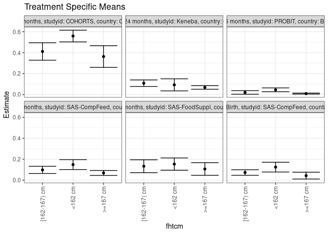

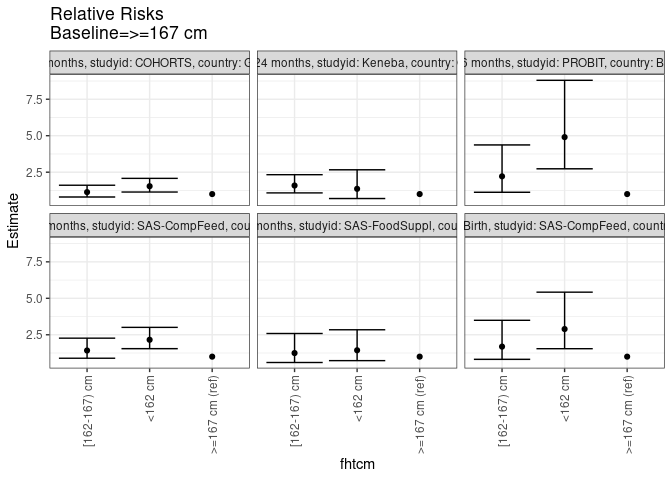

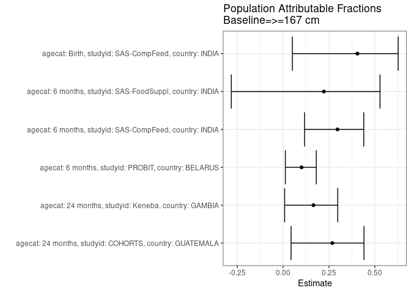

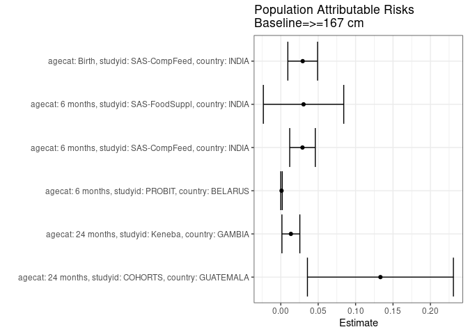

## Results Table

### Parameter: TSM

| agecat | studyid | country | intervention_level | baseline_level | estimate | ci_lower | ci_upper |
| --- | --- | --- | --- | --- | --- | --- | --- |
| Birth | SAS-CompFeed | INDIA | >=167 cm | NA | 0.0430804 | 0.0104106 | 0.0757502 |
| Birth | SAS-CompFeed | INDIA | <162 cm | NA | 0.1246073 | 0.0778741 | 0.1713405 |
| Birth | SAS-CompFeed | INDIA | [162-167) cm | NA | 0.0727026 | 0.0464944 | 0.0989108 |
| 6 months | PROBIT | BELARUS | >=167 cm | NA | 0.0091513 | 0.0042279 | 0.0140747 |
| 6 months | PROBIT | BELARUS | <162 cm | NA | 0.0448718 | 0.0264882 | 0.0632554 |
| 6 months | PROBIT | BELARUS | [162-167) cm | NA | 0.0202703 | 0.0030201 | 0.0375204 |
| 6 months | SAS-CompFeed | INDIA | >=167 cm | NA | 0.0688768 | 0.0454703 | 0.0922833 |
| 6 months | SAS-CompFeed | INDIA | <162 cm | NA | 0.1485553 | 0.1014412 | 0.1956695 |
| 6 months | SAS-CompFeed | INDIA | [162-167) cm | NA | 0.0979531 | 0.0637516 | 0.1321546 |
| 6 months | SAS-FoodSuppl | INDIA | >=167 cm | NA | 0.1066498 | 0.0463124 | 0.1669873 |
| 6 months | SAS-FoodSuppl | INDIA | <162 cm | NA | 0.1532643 | 0.0947358 | 0.2117928 |
| 6 months | SAS-FoodSuppl | INDIA | [162-167) cm | NA | 0.1328454 | 0.0711215 | 0.1945692 |
| 24 months | COHORTS | GUATEMALA | >=167 cm | NA | 0.3630217 | 0.2594640 | 0.4665793 |
| 24 months | COHORTS | GUATEMALA | <162 cm | NA | 0.5586968 | 0.5025276 | 0.6148661 |
| 24 months | COHORTS | GUATEMALA | [162-167) cm | NA | 0.4112931 | 0.3280290 | 0.4945573 |
| 24 months | Keneba | GAMBIA | >=167 cm | NA | 0.0682095 | 0.0509581 | 0.0854609 |
| 24 months | Keneba | GAMBIA | <162 cm | NA | 0.0927835 | 0.0350244 | 0.1505426 |
| 24 months | Keneba | GAMBIA | [162-167) cm | NA | 0.1081794 | 0.0768965 | 0.1394623 |

### Parameter: E(Y)

| agecat | studyid | country | intervention_level | baseline_level | estimate | ci_lower | ci_upper |
| --- | --- | --- | --- | --- | --- | --- | --- |
| Birth | SAS-CompFeed | INDIA | NA | NA | 0.0723861 | 0.0394059 | 0.1053662 |
| 6 months | PROBIT | BELARUS | NA | NA | 0.0101732 | 0.0047762 | 0.0155702 |
| 6 months | SAS-CompFeed | INDIA | NA | NA | 0.0978934 | 0.0736377 | 0.1221492 |
| 6 months | SAS-FoodSuppl | INDIA | NA | NA | 0.1370968 | 0.1020978 | 0.1720958 |
| 24 months | COHORTS | GUATEMALA | NA | NA | 0.4961977 | 0.4534290 | 0.5389664 |
| 24 months | Keneba | GAMBIA | NA | NA | 0.0817271 | 0.0668124 | 0.0966418 |

### Parameter: RR

| agecat | studyid | country | intervention_level | baseline_level | estimate | ci_lower | ci_upper |
| --- | --- | --- | --- | --- | --- | --- | --- |
| Birth | SAS-CompFeed | INDIA | >=167 cm | >=167 cm | 1.000000 | 1.0000000 | 1.000000 |
| Birth | SAS-CompFeed | INDIA | <162 cm | >=167 cm | 2.892433 | 1.5440093 | 5.418471 |
| Birth | SAS-CompFeed | INDIA | [162-167) cm | >=167 cm | 1.687600 | 0.8155783 | 3.491995 |
| 6 months | PROBIT | BELARUS | >=167 cm | >=167 cm | 1.000000 | 1.0000000 | 1.000000 |
| 6 months | PROBIT | BELARUS | <162 cm | >=167 cm | 4.903343 | 2.7323237 | 8.799388 |
| 6 months | PROBIT | BELARUS | [162-167) cm | >=167 cm | 2.215024 | 1.1232780 | 4.367869 |
| 6 months | SAS-CompFeed | INDIA | >=167 cm | >=167 cm | 1.000000 | 1.0000000 | 1.000000 |
| 6 months | SAS-CompFeed | INDIA | <162 cm | >=167 cm | 2.156829 | 1.5465267 | 3.007972 |
| 6 months | SAS-CompFeed | INDIA | [162-167) cm | >=167 cm | 1.422150 | 0.8917717 | 2.267969 |
| 6 months | SAS-FoodSuppl | INDIA | >=167 cm | >=167 cm | 1.000000 | 1.0000000 | 1.000000 |
| 6 months | SAS-FoodSuppl | INDIA | <162 cm | >=167 cm | 1.437080 | 0.7267624 | 2.841643 |
| 6 months | SAS-FoodSuppl | INDIA | [162-167) cm | >=167 cm | 1.245622 | 0.5999228 | 2.586289 |
| 24 months | COHORTS | GUATEMALA | >=167 cm | >=167 cm | 1.000000 | 1.0000000 | 1.000000 |
| 24 months | COHORTS | GUATEMALA | <162 cm | >=167 cm | 1.539018 | 1.1401236 | 2.077473 |
| 24 months | COHORTS | GUATEMALA | [162-167) cm | >=167 cm | 1.132971 | 0.7999836 | 1.604563 |
| 24 months | Keneba | GAMBIA | >=167 cm | >=167 cm | 1.000000 | 1.0000000 | 1.000000 |
| 24 months | Keneba | GAMBIA | <162 cm | >=167 cm | 1.360272 | 0.6947196 | 2.663436 |
| 24 months | Keneba | GAMBIA | [162-167) cm | >=167 cm | 1.585988 | 1.0800767 | 2.328869 |

### Parameter: PAR

| agecat | studyid | country | intervention_level | baseline_level | estimate | ci_lower | ci_upper |
| --- | --- | --- | --- | --- | --- | --- | --- |
| Birth | SAS-CompFeed | INDIA | >=167 cm | NA | 0.0293056 | 0.0094352 | 0.0491760 |
| 6 months | PROBIT | BELARUS | >=167 cm | NA | 0.0010219 | 0.0000057 | 0.0020381 |
| 6 months | SAS-CompFeed | INDIA | >=167 cm | NA | 0.0290167 | 0.0119327 | 0.0461006 |
| 6 months | SAS-FoodSuppl | INDIA | >=167 cm | NA | 0.0304470 | -0.0232623 | 0.0841562 |
| 24 months | COHORTS | GUATEMALA | >=167 cm | NA | 0.1331760 | 0.0356321 | 0.2307200 |
| 24 months | Keneba | GAMBIA | >=167 cm | NA | 0.0135176 | 0.0015474 | 0.0254877 |

### Parameter: PAF

| agecat | studyid | country | intervention_level | baseline_level | estimate | ci_lower | ci_upper |
| --- | --- | --- | --- | --- | --- | --- | --- |
| Birth | SAS-CompFeed | INDIA | >=167 cm | NA | 0.4048517 | 0.0504783 | 0.6269685 |
| 6 months | PROBIT | BELARUS | >=167 cm | NA | 0.1004533 | 0.0123077 | 0.1807325 |
| 6 months | SAS-CompFeed | INDIA | >=167 cm | NA | 0.2964109 | 0.1168736 | 0.4394487 |
| 6 months | SAS-FoodSuppl | INDIA | >=167 cm | NA | 0.2220837 | -0.2822732 | 0.5280618 |
| 24 months | COHORTS | GUATEMALA | >=167 cm | NA | 0.2683931 | 0.0433336 | 0.4405065 |
| 24 months | Keneba | GAMBIA | >=167 cm | NA | 0.1653988 | 0.0084770 | 0.2974857 |